# Analisis Exploratorio Ejercicio1

Fredy Velasquez, Angel Higueros

2023-08-18

## Ejercicio 1: Caracteres manuscritos

```r
library(ggplot2)
library(dplyr)
library(tidyverse)


# Read the dataset
db<-read.csv('train.csv')
summary(db)
```

[output not shown]

[output cut: 1268 more lines]

```
##  Max.   :255.0000   Max.   :255.0000   Max.   :255.0000   Max.   :254.0000
##     pixel775           pixel776            pixel777            pixel778
##  Min.   :  0.0000   Min.   :  0.00000   Min.   :  0.00000   Min.   :  0.00000
##  1st Qu.:  0.0000   1st Qu.:  0.00000   1st Qu.:  0.00000   1st Qu.:  0.00000
##  Median :  0.0000   Median :  0.00000   Median :  0.00000   Median :  0.00000
##  Mean   :  0.1171   Mean   :  0.05902   Mean   :  0.02019   Mean   :  0.01724
##  3rd Qu.:  0.0000   3rd Qu.:  0.00000   3rd Qu.:  0.00000   3rd Qu.:  0.00000
##  Max.   :254.0000   Max.   :253.00000   Max.   :253.00000   Max.   :254.00000
##     pixel779           pixel780    pixel781    pixel782    pixel783
##  Min.   : 0.00000   Min.   :0   Min.   :0   Min.   :0   Min.   :0
##  1st Qu.: 0.00000   1st Qu.:0   1st Qu.:0   1st Qu.:0   1st Qu.:0
##  Median : 0.00000   Median :0   Median :0   Median :0   Median :0
##  Mean   : 0.00286   Mean   :0   Mean   :0   Mean   :0   Mean   :0
##  3rd Qu.: 0.00000   3rd Qu.:0   3rd Qu.:0   3rd Qu.:0   3rd Qu.:0
##  Max.   :62.00000   Max.   :0   Max.   :0   Max.   :0   Max.   :0
```

Como se observa en el resumen el dataset cuenta con 785 columnas y 42000 filas donde la idea es la columna label es el dígito dibujado por el usuario. El resto de las columnas contienen los valores de cada píxel de la imagen asociada. Cada imagen tiene 28 píxeles de altura y 28 píxeles de ancho, para un total de 784 píxeles en total. Cada píxel tiene un único valor de píxel asociado, que indica la luminosidad u oscuridad de ese píxel, con números más altos que significan más oscuros. Este valor de píxel es un número entero entre 0 y 255, inclusive

### Analisis Exploratorio

Para poder entrar en contexto con los datos primero veremos la cantidad de labels o digitos proporcionados, con la intencion de determinar que digito contiene mas pixeles

```r
table(db$label)
```

```
##
##    0    1    2    3    4    5    6    7    8    9
## 4132 4684 4177 4351 4072 3795 4137 4401 4063 4188
```

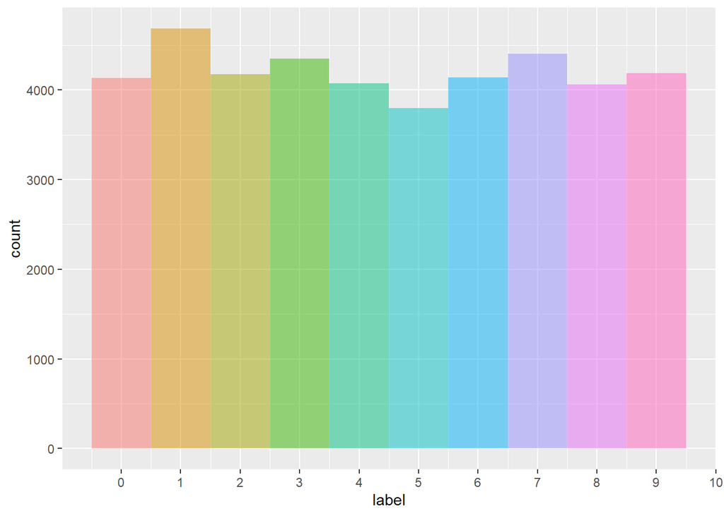

```r
ggplot(data = db) + geom_histogram(aes(x=label,fill=factor(label)),bins=10, position = "stack",alpha = 0.5)+theme(legend.position="none")+ scale_x_continuous(breaks = seq(0, 100, 1.))
```

Tras observar graficamente vemos que el numero 1 es el que mas filas tiene guardado datos, dando a entender que puede ser el numero mas dificil a predicir por ello es necesario tener mas filas con datos de este,y el siguiente numero es el 7, esto con la idea que estos numeros tienden a confundirse por ello fue necesario mas iteraciones de prueba para posterior almacenar su resultado en este dataset.

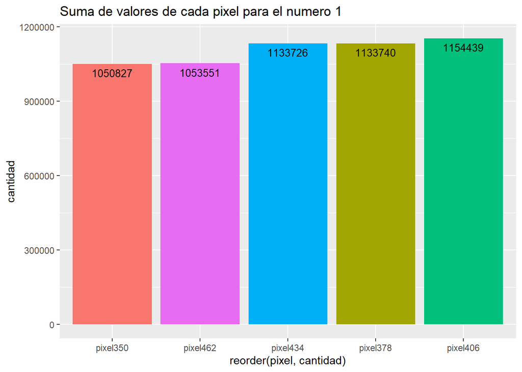

```r
number1<- subset(db, label == 1)
#Save all one's in new dataframe
dt<-colSums(number1[,-1])


dtF<-data.frame (pixel  = c(colnames(number1[,-1])),
                  cantidad = c(dt)
                  )

dtF2 <- dtF[order(-dtF$cantidad),]
dtF2<-head(dtF2,n=5)


ggplot(data=dtF2, aes(x=reorder(pixel,cantidad),y=cantidad, fill=pixel)) +
  geom_bar(stat="identity", position=position_dodge())+
  geom_text(aes(label=cantidad), vjust=1.6, color="black",
            position = position_dodge(0.9), size=3.5)+
  labs(title="Suma de valores de cada pixel para el numero 1 ")+
  theme(legend.position="none")
```

Tal como se observa en la grafica anterior, se puede observar que el pixel numero 406 del numero 1 presenta mas cambios de color, o por otro lado es un pixel que en su mayoria esta pintado o tiene un valor del color. Analisis del pixel 406

```r
number1Group<-subset(db,db$label==1)
summary(as.factor(number1Group$pixel406))
```

```
##     253     254     255     252     251     250     249       0     240     243
##    1680    1129     758     475      74      43      19      16      16      16
##     248     246     241     247     244     233     235     230     242     196
##      14      13      12      12      11      10      10       9       9       8
##     209     216     221     227     234     236     239     191     207     231
##       8       8       8       8       8       8       8       7       7       7
##     195     203     238     151     223     224     225     232     128     154
##       6       6       6       5       5       5       5       5       4       4
##     155     159     177     188     198     200     204     205     206     214
##       4       4       4       4       4       4       4       4       4       4
##     215     218     222     237     138     148     157     170     172     184
##       4       4       4       4       3       3       3       3       3       3
##     192     197     210     213     217     220     226     228     245      32
##       3       3       3       3       3       3       3       3       3       2
##      34      51      56      57      64      74     102     115     116     117
##       2       2       2       2       2       2       2       2       2       2
##     119     124     126     134     143     144     149     150     156     165
##       2       2       2       2       2       2       2       2       2       2
##     171     182     185     186     189     190     194     202     211 (Other)
##       2       2       2       2       2       2       2       2       2      61
```

como se logra observar anteriormente el pixel 406 tiene mas cambios de color, demostrando que efectivamente este pixel si cambia mucho el color de su relleno.

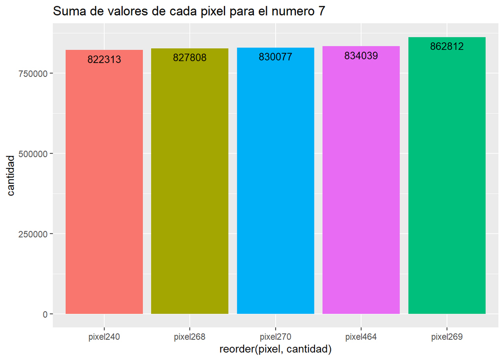

```r
number7<- subset(db, label == 7)
#Save all one's in new dataframe
dt7<-colSums(number7[,-1])


dtF7<-data.frame (pixel  = c(colnames(number7[,-1])),
                  cantidad = c(dt7)
                  )

dtF27 <- dtF7[order(-dtF7$cantidad),]
dtF27<-head(dtF27,n=5)


ggplot(data=dtF27, aes(x=reorder(pixel,cantidad),y=cantidad, fill=pixel)) +
  geom_bar(stat="identity", position=position_dodge())+
  geom_text(aes(label=cantidad), vjust=1.6, color="black",
            position = position_dodge(0.9), size=3.5)+
  labs(title="Suma de valores de cada pixel para el numero 7 ")+
  theme(legend.position="none")
```

Tras obsevar los pixeles del numero 7 se observo que en este caso el pixel con mas color o mas datos es el pixel 269, indicando que a pesar que el numero 1 y 7 se parecen los pixeles con mas color son distintos.

```r
number7Group<-subset(db,db$label==7)
summary(as.factor(number7Group$pixel269))
```

```
##     253     252     254       0     255     251     250     234     217     235
##    1065     584     508     326     147      44      40      31      24      24
##     243     249     128     191     236     241     244     200     233     247
##      23      22      20      19      19      19      19      18      18      18
##     215     240     195     230     232     245     183     226     228     246
##      17      17      14      14      14      14      13      13      13      13
##     248      37      71      96     114     139     170     184     214     231
##      13      12      12      12      12      12      12      12      12      12
##     238     116     140     169     222     223      64      86     106     127
##      12      11      11      11      11      11      10      10      10      10
##     154     168     176     187     198     202     210     220     221     229
##      10      10      10      10      10      10      10      10      10      10
##     242      10     113     118     126     131     149     156     188     213
##      10       9       9       9       9       9       9       9       9       9
##     237      57      84     102     133     163     181     199     203     205
##       9       8       8       8       8       8       8       8       8       8
##     208     227     239       2      23      56      82     138     158     159
##       8       8       8       7       7       7       7       7       7       7
##     160     174     180     192     216     225       9      17      18 (Other)
##       7       7       7       7       7       7       6       6       6     638
```

como se logra observar anteriormente el pixel 269 tiene mas cambios de color, demostrando que efectivamente este pixel si cambia mucho el color de su relleno. De hecho, se observa que este pixel de este numero tiene mas cambios que el pixel 406 del numero 1.